# All_Village

```python
import pandas as pd
import numpy as np
import matplotlib.pyplot as plt
import matplotlib.patheffects as pe
import seaborn as sns
```

```python
df = pd.read_csv('Village_profile_UBA_(Responses)-Form_Responses_1_Copy.csv')
```

```python
df.head()
```

|  | Timestamp | Survey type | Village Name | Household ID (House No.) | Name of Head of Household | Gender | Contact Number of Household | Social Category | Total Family Members | Main Occupation | ... | Livelihood Schemes [PM Fasal Bima] | Livelihood Schemes [Pension Schemes] | Awareness about Gram Sabha meetings | Participation in village development | Major village issues | Most urgent need of the village | Suggestions for village development | Enumerator Name | UID | Date |
| --- | --- | --- | --- | --- | --- | --- | --- | --- | --- | --- | --- | --- | --- | --- | --- | --- | --- | --- | --- | --- | --- |
| 0 | 01-12-2026 13:22 | Baseline | Bajhedi | NaN | Mohan Singh | Male | 9914104719 | General | 4 | Service | ... | Aware | Aware | No | Occasional | Water, Education, Employment | Road improvements | Making of roads | Hitanshi | 25bbl70047 | 01-12-2026 |
| 1 | 1/13/2026 12:48:58 | Baseline | Baroli | 144 | Harshant veer | Male | NaN | Scheduled Tribe | 4 | Service | ... | Aware | Aware | Yes | Occasional | Water, Environment | Drainage system | Drainage system | Yashmi and Aditi | 25bcs12827 and 25bcs10021 | 1/13/2026 |
| 2 | 01-12-2026 11:48 | Baseline | Bhago Majra | NaN | Jaswinder kour | Female | 9781068967 | General | 6 | Agriculture | ... | Not Aware | Not Aware | No | Never | Health | Healthcare | Cleaning of waste | Bhagyashree | 24btt10013 | 01-12-2026 |
| 3 | 01-12-2026 13:48 | Baseline | Bajhedi | NaN | Gurinder kaur | Female | 8872445393 | General | 4 | Business | ... | Not Aware | Not Aware | Yes | Never | Water, Health, Environment | Transport, Dispensary and pond purification | Regular transport and dispensary | Pushp Ankit kotwal | 25bbl70011 | 01-12-2026 |
| 4 | 1/13/2026 11:19:16 | Baseline | Bhago Majra | NaN | Kulwant Singh | Male | 7696486215 | General | 5 | Agriculture | ... | Aware | Aware | Yes | Occasional | Environment | All good there is gym in village,school ,every... | No | Kushagra Sharma | 25BBE10175 | 1/13/2026 |

5 rows × 75 columns

```python
print("Dataset Shape:", df.shape)
```

```
Dataset Shape: (855, 75)
```

```python
df.columns = df.columns.str.strip()
df['Total Family Members'] = pd.to_numeric(df['Total Family Members'], errors='coerce')
```

```python
missing_values = df.isnull().sum().reset_index()
missing_values.columns = ['Column Name', 'Missing Count']
missing_values[missing_values['Missing Count'] > 0]
```

|  | Column Name | Missing Count |
| --- | --- | --- |
| 3 | Household ID (House No.) | 498 |
| 4 | Name of Head of Household | 1 |
| 6 | Contact Number of Household | 364 |
| 8 | Total Family Members | 1 |
| 15 | Pregnant women received ANC services | 209 |
| 17 | Nutritional issues of children | 784 |
| 18 | Common diseases | 435 |
| 27 | Type of school | 122 |
| 30 | Reason for dropout | 519 |
| 31 | Access to digital devices | 50 |
| 42 | Drainage system | 42 |
| 48 | Renewable energy usage | 578 |
| 49 | Disaster vulnerability | 522 |
| 62 | Migration for employment | 493 |
| 70 | Most urgent need of the village | 27 |
| 71 | Suggestions for village development | 22 |
| 73 | UID | 1 |

```python
df.columns
```

```
Index(['Timestamp', 'Survey type', 'Village Name', 'Household ID (House No.)',
       'Name of Head of Household', 'Gender', 'Contact Number of Household',
       'Social Category', 'Total Family Members', 'Main Occupation',
       'Approx. Annual Household Income',
       'Distance to nearest health facility', 'Type of facility used',
       'ASHA/ANM visit', 'Immunization status of children (0-5)',
       'Pregnant women received ANC services',
       'Last delivery was institutional  (in any hospital)',
       'Nutritional issues  of children', 'Common diseases',
       'Toilet availability', 'Handwashing with soap',
       'Health Schemes   [Ayushman Bharat (PM-JAY)]',
       'Health Schemes   [Janani Suraksha Yojana]',
       'Health Schemes   [Janani Shishu Suraksha Karyakram]',
       'Health Schemes   [Poshan Abhiyaan / ICDS]',
       'Literacy status of household', 'Children enrolled in school',
       'Type of school', 'Distance to nearest school',
       'School dropout cases  in the household', 'Reason for dropout',
       'Access to digital devices',
       'Girls continuing education beyond Class X',
       'Need for remedial/coaching support', 'Education Schemes   [PM POSHAN]',
       'Education Schemes   [Pre/Post Matric Scholarship]',
       'Education Schemes   [National Merit Scholarship]',
       'Source of drinking water', 'Availability  of water supply',
       'Quality of drinking water',
       'Household water treatment  through purifier',
       'Solid waste disposal method', 'Drainage system',
       'Open defecation in village', 'Presence of pond/water body',
       'Condition of pond', 'Usage of pond', 'Major environmental problems',
       'Renewable energy usage', 'Disaster vulnerability',
       'Willingness to participate',
       'Household women  engaged in income activity', 'Type of activity',
       'SHG membership', 'Bank account in woman’s name',
       'Role of women in decision-making',
       'Women Schemes   [Pradhan Mantri Matru Vandana Yojana]',
       'Women Schemes   [NRLM]', 'Women Schemes   [Beti Bachao Beti Padhao]',
       'Women Schemes   [Sukanya Samriddhi]',
       'Skill-trained member in household', 'Skills required',
       'Migration for employment', 'Livelihood Schemes   [MGNREGA]',
       'Livelihood Schemes   [PM-KISAN]',
       'Livelihood Schemes   [PM Fasal Bima]',
       'Livelihood Schemes   [Pension Schemes]',
       'Awareness about Gram Sabha meetings',
       'Participation in village development', 'Major village issues',
       'Most urgent need of the village',
       'Suggestions for village development', 'Enumerator Name', 'UID',
       'Date'],
      dtype='object')
```

```python
df.info()
```

```
<class 'pandas.core.frame.DataFrame'>
RangeIndex: 855 entries, 0 to 854
Data columns (total 75 columns):
 #   Column                                                 Non-Null Count  Dtype
---  ------                                                 --------------  -----
 0   Timestamp                                              855 non-null    object
 1   Survey type                                            855 non-null    object
 2   Village Name                                           855 non-null    object
 3   Household ID (House No.)                               357 non-null    object
 4   Name of Head of Household                              854 non-null    object
 5   Gender                                                 855 non-null    object
 6   Contact Number of Household                            491 non-null    object
 7   Social Category                                        855 non-null    object
 8   Total Family Members                                   854 non-null    float64
 9   Main Occupation                                        855 non-null    object
```

[output cut: 67 more lines]

# Socio-Economic Indicators

# 1. Income Distribution Index

```python
income_counts = df['Approx. Annual Household Income'].value_counts()
```

```python
percentage_income = (income_counts/income_counts.sum())*100
percentage_income
```

```
Approx. Annual Household Income
1-3 lakh    34.035088
<1 lakh     33.216374
3-5 lakh    20.701754
>5 lakh     12.046784
Name: count, dtype: float64
```

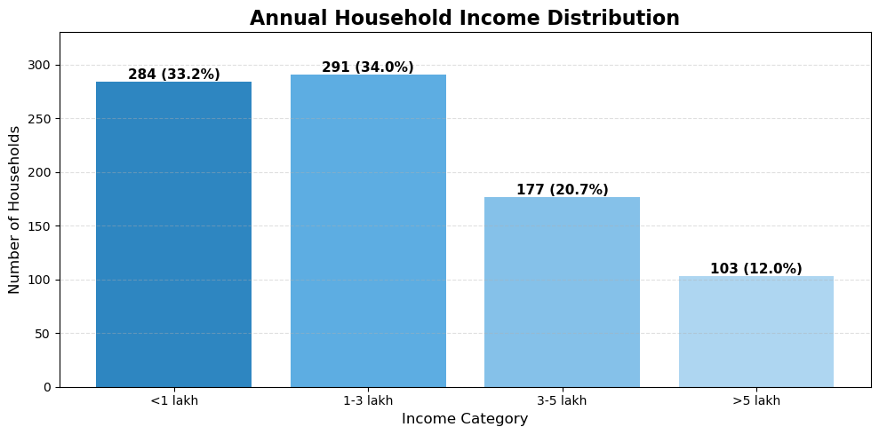

```python
order = ['<1 lakh', '1-3 lakh', '3-5 lakh', '>5 lakh']
income_counts = df['Approx. Annual Household Income'].value_counts()
income_counts = income_counts[order]

plt.figure(figsize=(10,5))

colors = ['#2E86C1', '#5DADE2', '#85C1E9', '#AED6F1']
bars = plt.bar(income_counts.index, income_counts.values, color=colors)

total = income_counts.sum()

for bar in bars:
    height = bar.get_height()
    percent = (height / total) * 100

    plt.text(bar.get_x() + bar.get_width()/2,
             height,
             f'{int(height)} ({percent:.1f}%)',
             ha='center',
             va='bottom',
             fontsize=11,
             fontweight='bold')

plt.title("Annual Household Income Distribution", fontsize=16, fontweight='bold')
plt.xlabel("Income Category", fontsize=12)
plt.ylabel("Number of Households", fontsize=12)
plt.ylim(0, 330)
plt.grid(axis='y', linestyle='--', alpha=0.4)
plt.tight_layout()
plt.show()
```

Findings- 33.2% households earn below ₹1 lakh 34.0% earn ₹1–3 lakh 20.7% earn ₹3–5 lakh 12.0% earn above ₹5 lakh Interpretation- The village shows a moderately low-income structure, with nearly 67% households earning below ₹3 lakh annually. Only 12% households fall in higher income brackets (>₹5 lakh), indicating limited upward economic mobility.

# 2. Occupational Diversity Indicator

```python
occupation_dist = df['Main Occupation'].value_counts(normalize=True) * 100
occupation_dist = occupation_dist.round(2)
print(occupation_dist)
```

```
Main Occupation
Agriculture                       36.73
Labour                            22.34
Service                           20.94
Business                           9.82
Agriculture, Business              2.81
Agriculture, Service               2.46
Agriculture, Labour                1.87
Service, Business                  1.40
Labour, Service                    1.05
Labour, Business                   0.23
Agriculture, Labour, Service       0.12
Agriculture, Service, Business     0.12
Agriculture, Labour, Business      0.12
Name: proportion, dtype: float64
```

```python
df['Main Occupation'].value_counts()
```

```
Main Occupation
Agriculture                       314
Labour                            191
Service                           179
Business                           84
Agriculture, Business              24
Agriculture, Service               21
Agriculture, Labour                16
Service, Business                  12
Labour, Service                     9
Labour, Business                    2
Agriculture, Labour, Service        1
Agriculture, Service, Business      1
Agriculture, Labour, Business       1
Name: count, dtype: int64
```

```python
df['Approx. Annual Household Income'] = df['Approx. Annual Household Income'].str.strip()
df['Main Occupation'] = df['Main Occupation'].str.strip()
```

```python
order = ['<1 lakh', '1-3 lakh', '3-5 lakh', '>5 lakh']
df['Approx. Annual Household Income'] = pd.Categorical(
    df['Approx. Annual Household Income'],
    categories=order,
    ordered=True)

income_occupation = pd.crosstab(
    df['Main Occupation'],
    df['Approx. Annual Household Income'])
income_occupation
```

| Approx. Annual Household Income Main Occupation | <1 lakh | 1-3 lakh | 3-5 lakh | >5 lakh |
| --- | --- | --- | --- | --- |
| Agriculture | 79 | 127 | 79 | 29 |
| Agriculture, Business | 1 | 8 | 6 | 9 |
| Agriculture, Labour | 5 | 6 | 3 | 2 |
| Agriculture, Labour, Business | 0 | 1 | 0 | 0 |
| Agriculture, Labour, Service | 0 | 0 | 1 | 0 |
| Agriculture, Service | 4 | 5 | 7 | 5 |
| Agriculture, Service, Business | 0 | 0 | 0 | 1 |
| Business | 11 | 31 | 15 | 27 |
| Labour | 140 | 43 | 7 | 1 |
| Labour, Business | 0 | 2 | 0 | 0 |
| Labour, Service | 3 | 4 | 2 | 0 |
| Service | 41 | 59 | 51 | 28 |
| Service, Business | 0 | 5 | 6 | 1 |

```python
occupations = df['Main Occupation'].value_counts().index
income_occupation = income_occupation.loc[occupations]
income_occupation
```

| Approx. Annual Household Income Main Occupation | <1 lakh | 1-3 lakh | 3-5 lakh | >5 lakh |
| --- | --- | --- | --- | --- |
| Agriculture | 79 | 127 | 79 | 29 |
| Labour | 140 | 43 | 7 | 1 |
| Service | 41 | 59 | 51 | 28 |
| Business | 11 | 31 | 15 | 27 |
| Agriculture, Business | 1 | 8 | 6 | 9 |
| Agriculture, Service | 4 | 5 | 7 | 5 |
| Agriculture, Labour | 5 | 6 | 3 | 2 |
| Service, Business | 0 | 5 | 6 | 1 |
| Labour, Service | 3 | 4 | 2 | 0 |
| Labour, Business | 0 | 2 | 0 | 0 |
| Agriculture, Labour, Service | 0 | 0 | 1 | 0 |
| Agriculture, Service, Business | 0 | 0 | 0 | 1 |
| Agriculture, Labour, Business | 0 | 1 | 0 | 0 |

```python
top_occupations = df['Main Occupation'].value_counts().head(5).index
income_occupation = income_occupation.loc[top_occupations]
```

```python
income_occupation
```

| Approx. Annual Household Income Main Occupation | <1 lakh | 1-3 lakh | 3-5 lakh | >5 lakh |
| --- | --- | --- | --- | --- |
| Agriculture | 79 | 127 | 79 | 29 |
| Labour | 140 | 43 | 7 | 1 |
| Service | 41 | 59 | 51 | 28 |
| Business | 11 | 31 | 15 | 27 |
| Agriculture, Business | 1 | 8 | 6 | 9 |

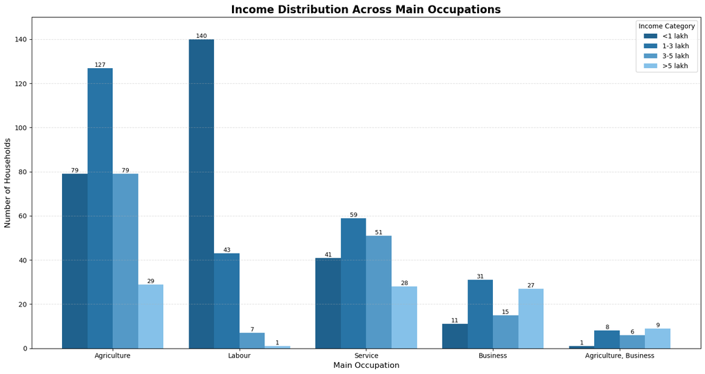

```python
plt.figure(figsize=(15,8))

x = np.arange(len(income_occupation.index))
width = 0.2
colors = ['#1F618D', '#2874A6', '#5499C7', '#85C1E9']

for i, income_cat in enumerate(order):
    bars = plt.bar(x + i*width,
                   income_occupation[income_cat],
                   width,
                   label=income_cat,
                   color=colors[i])

    for bar in bars:
        height = bar.get_height()
        if height > 0:
            plt.text(bar.get_x() + bar.get_width()/2,
                     height,
                     int(height),
                     ha='center',
                     va='bottom',
                     fontsize=9)

plt.xticks(x + width*1.5, income_occupation.index)
plt.xlabel("Main Occupation", fontsize=12)
plt.ylabel("Number of Households", fontsize=12)
plt.title("Income Distribution Across Main Occupations", fontsize=16, fontweight='bold')

plt.legend(title="Income Category")
plt.grid(axis='y', linestyle='--', alpha=0.4)
plt.ylim(0, income_occupation.values.max()+10)
plt.tight_layout()
plt.show()
```

```python
avg_family_size = df['Total Family Members'].mean()
print("Average Family Size:", round(avg_family_size,2))
```

```
Average Family Size: 5.63
```

Average = 5.63 members per household Interpretation- The average family size of 5.6 suggests moderate dependency burden, which may strain income in lower-income households.

# 3.Social Inclusion Profile

```python
df['Social Category'].value_counts()
```

```
Social Category
General            483
Scheduled Caste    209
OBC                150
Scheduled Tribe     13
Name: count, dtype: int64
```

```python
social_category = df['Social Category'].value_counts()
per_social_category = round((social_category/social_category.sum())*100,2)
per_social_category
```

```
Social Category
General            56.49
Scheduled Caste    24.44
OBC                17.54
Scheduled Tribe     1.52
Name: count, dtype: float64
```

```python
round(pd.crosstab(df['Social Category'], df['Livelihood Schemes   [PM-KISAN]'], normalize='index') * 100,2)
```

| Livelihood Schemes [PM-KISAN] Social Category | Applied | Availed | Aware | Not Aware |
| --- | --- | --- | --- | --- |
| General | 5.18 | 5.38 | 45.34 | 44.10 |
| OBC | 5.33 | 4.00 | 51.33 | 39.33 |
| Scheduled Caste | 4.78 | 1.91 | 44.98 | 48.33 |
| Scheduled Tribe | 0.00 | 0.00 | 69.23 | 30.77 |

```python
social = df['Social Category'].value_counts()
social = social.sort_values(ascending=False)
total = social.sum()
```

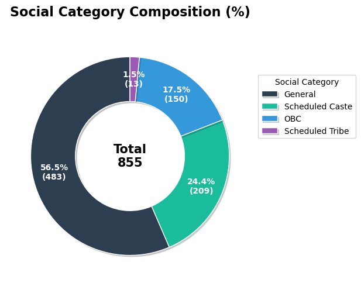

```python
colors = ['#2C3E50', '#1ABC9C', '#3498DB', '#9B59B6']
plt.figure(figsize=(10,5))

wedges, texts, autotexts = plt.pie(social.values, startangle=90, colors=colors, wedgeprops=dict(width=0.45, edgecolor='white'),
                                   pctdistance=0.78, autopct=lambda p: f"{p:.1f}%\n({int(round(p*total/100))})")
for wedge in wedges:
    wedge.set_path_effects([
        pe.SimplePatchShadow(offset=(2, -2), alpha=0.25),
        pe.Normal()])

for autotext in autotexts:
    autotext.set_fontsize(10)
    autotext.set_fontweight('bold')
    autotext.set_color('white')

plt.text(0, 0, f"Total\n{total}", ha='center', va='center', fontsize=15, fontweight='bold')
plt.title("Social Category Composition (%)", fontsize=16, fontweight='bold', pad=20)
plt.legend(wedges, social.index, title="Social Category", loc="center left", bbox_to_anchor=(1,0.7))
plt.tight_layout()
plt.show()
```

Social Composition- General: 56.5% SC: 24.4% OBC: 17.5% ST: 1.5% Interpretation- The village is socially mixed, but General category households dominate. SC/ST households form approximately 25.9% of the population, requiring focused inclusion in welfare schemes.

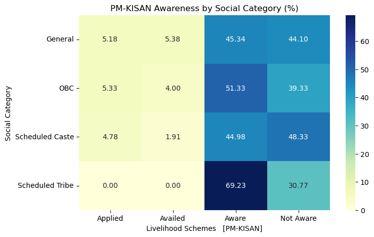

```python
scheme_equity = pd.crosstab(
    df['Social Category'],
    df['Livelihood Schemes   [PM-KISAN]'],
    normalize='index') * 100

plt.figure(figsize=(8,5))
sns.heatmap(scheme_equity,annot=True, cmap="YlGnBu", fmt=".2f")

plt.title("PM-KISAN Awareness by Social Category (%)")
plt.show()
```

# Health & Nutrition Indicators Framework

# Institutional Delivery Rate

```python
inst_delivery = df['Last delivery was institutional  (in any hospital)'].value_counts(normalize=True) * 100
round(inst_delivery,2)
```

```
Last delivery was institutional  (in any hospital)
YES    62.69
No     37.31
Name: proportion, dtype: float64
```

# Immunization Coverage (0–5 Years)

```python
immunization = df['Immunization status of children (0-5)'].value_counts()
immunization
```

```
Immunization status of children (0-5)
Fully            614
Partially        145
Not immunised     96
Name: count, dtype: int64
```

```python
immunization = df['Immunization status of children (0-5)'].value_counts(normalize=True) * 100
round(immunization,2)
```

```
Immunization status of children (0-5)
Fully            71.81
Partially        16.96
Not immunised    11.23
Name: proportion, dtype: float64
```

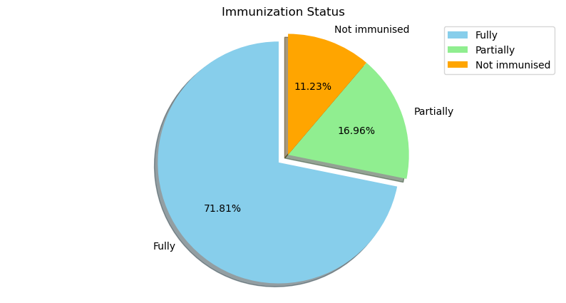

```python
plt.figure(figsize=(10,5))
plt.pie(immunization.values, labels=immunization.index, autopct='%1.2f%%', startangle=90, explode = [0.1, 0, 0], shadow=True,
       colors=['skyblue','lightgreen','orange'])
plt.title("Immunization Status")
plt.axis('equal')
plt.legend()
plt.show()
```

# Healthcare Accessibility Gap

```python
health_dist = df['Distance to nearest health facility'].value_counts()
health_dist
```

```
Distance to nearest health facility
1-5 km    373
>5 km     259
<1 km     223
Name: count, dtype: int64
```

```python
health_dist = round(df['Distance to nearest health facility'].value_counts(normalize=True) * 100,2)
health_dist
```

```
Distance to nearest health facility
1-5 km    43.63
>5 km     30.29
<1 km     26.08
Name: proportion, dtype: float64
```

```python
order = ['<1 km', '1-5 km', '>5 km']
health_dist = health_dist[order]
```

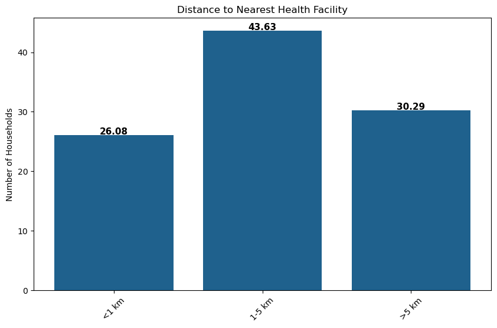

```python
plt.figure(figsize=(10,6))
bars = plt.bar(health_dist.index, health_dist.values, color='#1F618D')
for bar in bars:
    plt.text(bar.get_x() + bar.get_width()/2,
            bar.get_height() + 0.1,
            bar.get_height(),
            ha='center',
            fontsize=11,
            fontweight='bold')
plt.title("Distance to Nearest Health Facility")
plt.ylabel("Number of Households")
plt.xticks(rotation=45)
plt.show()
```

# Disease Prevalence Rate

```python
df['Common diseases'].value_counts()
```

```
Common diseases
BP                               168
BP, Diabetes                     103
Diabetes                          81
BP, Diabetes, Respiratory         18
Respiratory                       11
BP, Respiratory                   10
BP, None                           7
Diabetes, None                     3
BP, TB, Respiratory                3
TB                                 3
BP, Diabetes, TB                   3
BP, TB                             3
BP, Diabetes, TB, Respiratory      2
TB, None                           1
TB, Respiratory                    1
Diabetes, Respiratory              1
Diabetes, TB                       1
BP, Diabetes, None                 1
Name: count, dtype: int64
```

```python
diseases_rate = df['Common diseases'].notna().mean() * 100
print(f'Diseases Rate = {round(diseases_rate,2)}%')
```

```
Diseases Rate = 49.12%
```

```python
common_diseases = df['Common diseases'].str.split(',').explode().str.strip()
```

```python
common_diseases_count = common_diseases.value_counts()
common_diseases_count
```

```
Common diseases
BP             318
Diabetes       213
Respiratory     46
TB              17
None            12
Name: count, dtype: int64
```

```python
common_diseases_percentage = round((common_diseases_count/common_diseases_count.sum())*100,2)
common_diseases_percentage
```

```
Common diseases
BP             52.48
Diabetes       35.15
Respiratory     7.59
TB              2.81
None            1.98
Name: count, dtype: float64
```

# Scheme Awareness & Utilization (Health)

```python
pmjay = round(df['Health Schemes   [Ayushman Bharat (PM-JAY)]'].value_counts(normalize=True) * 100,2)
pmjay
```

```
Health Schemes   [Ayushman Bharat (PM-JAY)]
Aware        46.90
Not aware    34.04
Availed      10.18
Applied       8.89
Name: proportion, dtype: float64
```

```python
jsy = round(df['Health Schemes   [Janani Suraksha Yojana]'].value_counts(normalize=True) * 100,2)
jsy
```

```
Health Schemes   [Janani Suraksha Yojana]
Not aware    55.79
Aware        37.78
Availed       3.27
Applied       3.16
Name: proportion, dtype: float64
```

# Education & Digital Literacy Indicators

# 1. Household Literacy Rate

```python
literacy = df['Literacy status of household'].value_counts()
literacy
```

```
Literacy status of household
Partially literate    408
All literate          378
Mostly illiterate      69
Name: count, dtype: int64
```

```python
literacy_percent = round(df['Literacy status of household'].value_counts(normalize=True) * 100,2)
literacy_percent
```

```
Literacy status of household
Partially literate    47.72
All literate          44.21
Mostly illiterate      8.07
Name: proportion, dtype: float64
```

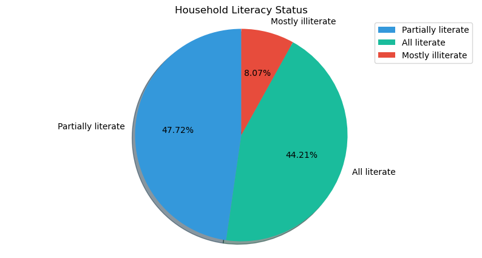

```python
plt.figure(figsize=(10,5))
plt.pie(literacy_percent.values, labels=literacy_percent.index, autopct='%1.2f%%', startangle=90, colors=['#3498DB','#1ABC9C','#E74C3C'], shadow=True)
plt.title("Household Literacy Status")
plt.axis('equal')
plt.legend()
plt.show()
```

# 2. School Dropout Rate

```python
dropout = df['School dropout cases  in the household'].value_counts()
dropout
```

```
School dropout cases  in the household
NO        679
YES       128
Partia     48
Name: count, dtype: int64
```

```python
dropout_percent = round(df['School dropout cases  in the household'].value_counts(normalize=True) * 100,2)
dropout_percent
```

```
School dropout cases  in the household
NO        79.42
YES       14.97
Partia     5.61
Name: proportion, dtype: float64
```

```python
reasons = df['Reason for dropout'].value_counts()
reasons
```

```
Reason for dropout
Financial                                     119
Lack of interest                               88
Domestic work                                  59
Migration                                      49
Financial, Domestic work                       10
Financial, Migration                            5
Domestic work, Lack of interest                 3
Financial, Lack of interest                     2
Financial, Domestic work, Lack of interest      1
Name: count, dtype: int64
```

```python
reasons_percent = round(df['Reason for dropout'].value_counts(normalize=True)*100,2)
reasons_percent
```

```
Reason for dropout
Financial                                     35.42
Lack of interest                              26.19
Domestic work                                 17.56
Migration                                     14.58
Financial, Domestic work                       2.98
Financial, Migration                           1.49
Domestic work, Lack of interest                0.89
Financial, Lack of interest                    0.60
Financial, Domestic work, Lack of interest     0.30
Name: proportion, dtype: float64
```

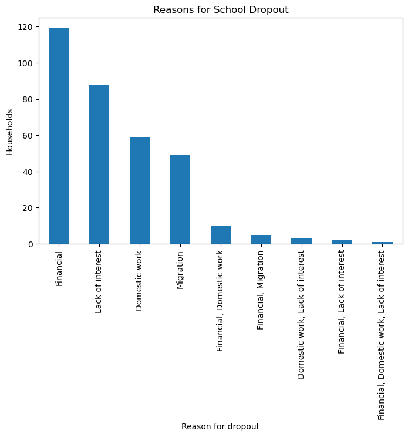

```python
plt.figure(figsize=(8,5))
reasons.plot(kind='bar')
plt.title("Reasons for School Dropout")
plt.ylabel("Households")
plt.xticks(rotation=90)
plt.show()
```

```python
reasons_strip = df['Reason for dropout'].str.split(',').explode().str.strip()
```

```python
reasons_value = reasons_strip.value_counts()
reasons_value
```

```
Reason for dropout
Financial           137
Lack of interest     94
Domestic work        73
Migration            54
Name: count, dtype: int64
```

```python
reasons_percentage = round((reasons_value/reasons_value.sum())*100,2)
reasons_percentage
```

```
Reason for dropout
Financial           38.27
Lack of interest    26.26
Domestic work       20.39
Migration           15.08
Name: count, dtype: float64
```

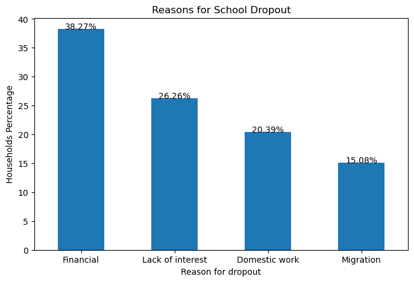

```python
plt.figure(figsize=(8,5))
reasons_percentage.plot(kind='bar')
for i, v in enumerate(reasons_percentage.values):
    plt.text(i, v, f'{v:.2f}%', ha='center')
plt.title("Reasons for School Dropout")
plt.ylabel("Households Percentage")
plt.xticks(rotation=0)
plt.show()
```

# 3. Digital Divide Index

```python
digital = df['Access to digital devices'].value_counts()
digital
```

```
Access to digital devices
Smartphone            599
Smartphone, Laptop    183
Laptop                 21
Smartphone, None        2
Name: count, dtype: int64
```

```python
digital_percent = round(df['Access to digital devices'].value_counts(normalize=True) * 100,2)
digital_percent
```

```
Access to digital devices
Smartphone            74.41
Smartphone, Laptop    22.73
Laptop                 2.61
Smartphone, None       0.25
Name: proportion, dtype: float64
```

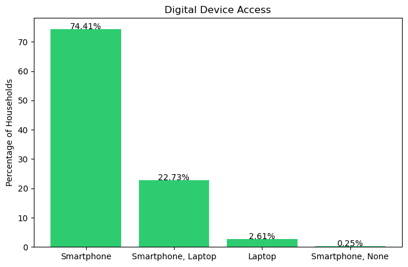

```python
plt.figure(figsize=(8,5))
plt.bar(digital_percent.index, digital_percent.values, color='#2ECC71')
for i,v in enumerate(digital_percent.values):
    plt.text(i, v, f"{v:.2f}%", ha='center')

plt.title("Digital Device Access")
plt.ylabel("Percentage of Households")
plt.show()
```

```python
digital_values = df['Access to digital devices'].str.split(',').explode().str.strip()
```

```python
digital_count = digital_values.value_counts()
digital_count
```

```
Access to digital devices
Smartphone    784
Laptop        204
None            2
Name: count, dtype: int64
```

```python
digital_percentage = round((digital_count/digital_count.sum())*100,2)
digital_percentage
```

```
Access to digital devices
Smartphone    79.19
Laptop        20.61
None           0.20
Name: count, dtype: float64
```

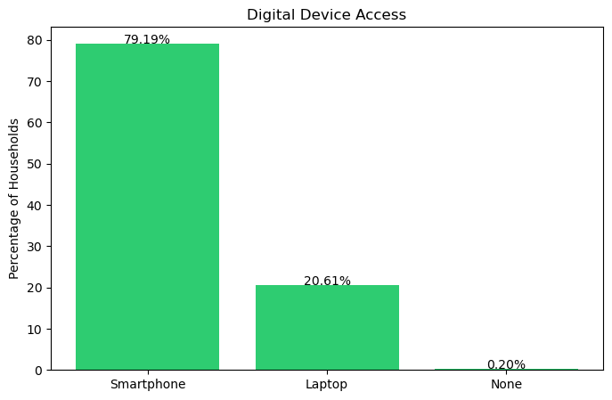

```python
plt.figure(figsize=(8,5))
plt.bar(digital_percentage.index, digital_percentage.values, color='#2ECC71')
for i,v in enumerate(digital_percentage.values):
    plt.text(i, v, f"{v:.2f}%", ha='center')

plt.title("Digital Device Access")
plt.ylabel("Percentage of Households")
plt.show()
```

# 4. Gender Gap in Higher Education

```python
girls_edu = df['Girls continuing education beyond Class X'].value_counts()
girls_edu
```

```
Girls continuing education beyond Class X
YES    630
No     225
Name: count, dtype: int64
```

```python
girls_edu_percent = round(df['Girls continuing education beyond Class X'].value_counts(normalize=True)*100,2)
girls_edu_percent
```

```
Girls continuing education beyond Class X
YES    73.68
No     26.32
Name: proportion, dtype: float64
```

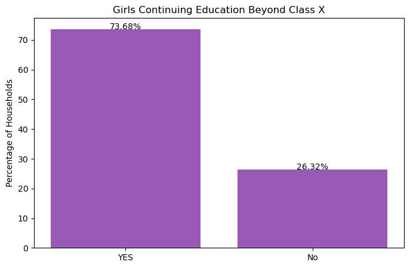

```python
plt.figure(figsize=(8,5))
plt.bar(girls_edu_percent.index, girls_edu_percent.values, color='#9B59B6')

for i,v in enumerate(girls_edu_percent.values):
    plt.text(i, v, f"{v:.2f}%", ha='center')

plt.title("Girls Continuing Education Beyond Class X")
plt.ylabel("Percentage of Households")
plt.show()
```

# 5. Remedial Support Demand

```python
remedial = df['Need for remedial/coaching support'].value_counts()
remedial
```

```
Need for remedial/coaching support
No     466
Yes    389
Name: count, dtype: int64
```

```python
remedial_percent = round(df['Need for remedial/coaching support'].value_counts(normalize=True)*100,2)
remedial_percent
```

```
Need for remedial/coaching support
No     54.5
Yes    45.5
Name: proportion, dtype: float64
```

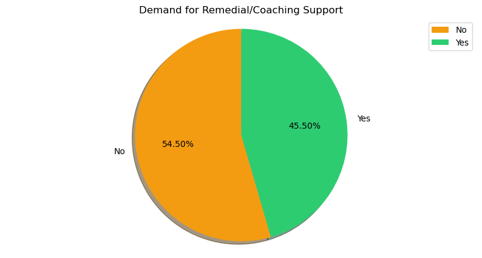

```python
plt.figure(figsize=(10,5))
plt.pie(remedial_percent.values, labels=remedial_percent.index, autopct='%1.2f%%', colors=['#F39C12','#2ECC71'], startangle=90, shadow=True)
plt.title("Demand for Remedial/Coaching Support")
plt.axis('equal')
plt.legend()
plt.show()
```

# Water, Sanitation & Hygiene (WASH) Indicators

# 1. Safe Drinking Water Access

```python
water_source = df['Source of drinking water'].value_counts()
water_source
```

```
Source of drinking water
Tap                                   527
Hand pump                              66
Tap, Hand pump                         53
Tap, Tanker                            46
Tanker                                 45
Tap, Hand pump, Well                   24
Tap, Well                              16
Well                                   15
Tap, Hand pump, Tanker                 15
Tap, Hand pump, Well, Tanker            8
Tap, Pond                               6
Hand pump, Tanker                       5
Tap, Hand pump, Pond, Tanker            4
Pond                                    3
Tap, Hand pump, Well, Pond, Tanker      3
Well, Tanker                            3
Hand pump, Well                         3
Hand pump, Well, Pond, Tanker           2
Tap, Well, Tanker                       2
Tap, Hand pump, Well, Pond              2
Pond, Tanker                            2
Tap, Well, Pond, Tanker                 1
Tap, Well, Pond                         1
Tap, Pond, Tanker                       1
Hand pump, Pond                         1
Hand pump, Well, Pond                   1
Name: count, dtype: int64
```

```python
water_source_split = df['Source of drinking water'].str.split(',').explode().str.strip()
```

```python
water_source_count = water_source_split.value_counts()
water_source_count
```

```
Source of drinking water
Tap          709
Hand pump    187
Tanker       137
Well          81
Pond          27
Name: count, dtype: int64
```

```python
water_source_percentage = round((water_source_count/water_source_count.sum())*100,2)
water_source_percentage
```

```
Source of drinking water
Tap          62.14
Hand pump    16.39
Tanker       12.01
Well          7.10
Pond          2.37
Name: count, dtype: float64
```

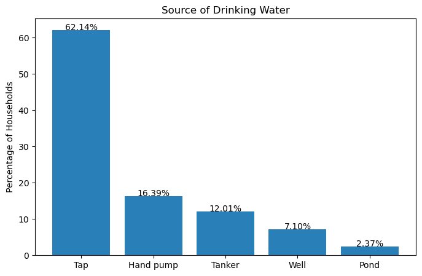

```python
plt.figure(figsize=(8,5))
bars = plt.bar(water_source_percentage.index, water_source_percentage.values, color='#2980B9')

for bar in bars:
    plt.text(bar.get_x() + bar.get_width()/2,
             bar.get_height(),
             f"{bar.get_height():.2f}%",
             ha='center')

plt.title("Source of Drinking Water")
plt.ylabel("Percentage of Households")
plt.xticks()
plt.show()
```

```python
water_quality = df['Quality of drinking water'].value_counts(normalize=True) * 100
round(water_quality,2)
```

```
Quality of drinking water
Good       72.40
Average    25.15
Poor        2.46
Name: proportion, dtype: float64
```

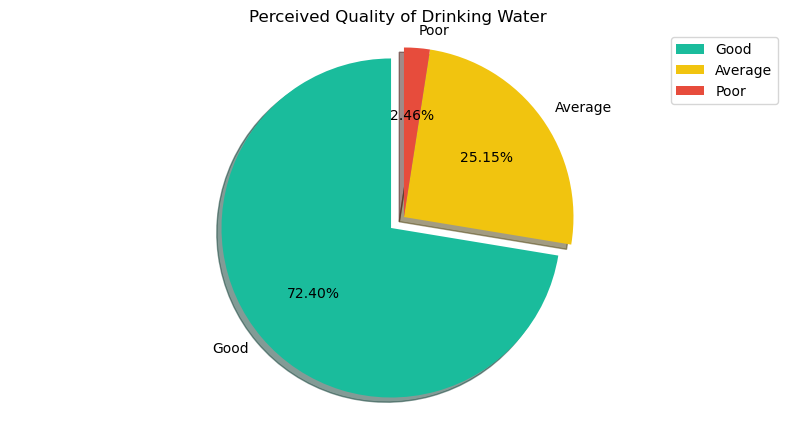

```python
plt.figure(figsize=(10,5))
plt.pie(water_quality.values, labels=water_quality.index, autopct='%1.2f%%', explode=[0.1,0,0], colors=['#1ABC9C','#F1C40F','#E74C3C'],
        startangle=90, shadow=True)
plt.title("Perceived Quality of Drinking Water")
plt.axis('equal')
plt.legend()
plt.show()
```

# 2. Sanitation Coverage

```python
toilet = df['Toilet availability'].value_counts(normalize=True) * 100
round(toilet,2)
```

```
Toilet availability
YES    95.79
NO      4.21
Name: proportion, dtype: float64
```

```python
handwash = df['Handwashing with soap'].value_counts(normalize=True) * 100
round(handwash,2)
```

```
Handwashing with soap
Always       81.29
Sometimes    16.73
Rarely        1.99
Name: proportion, dtype: float64
```

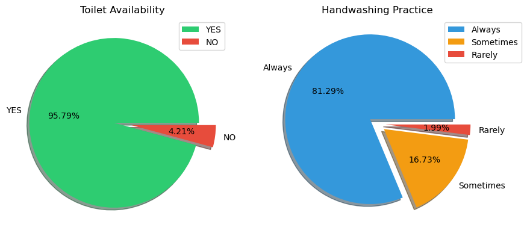

```python
plt.figure(figsize=(10,5))

plt.subplot(1,2,1)
plt.pie(toilet.values, labels=toilet.index, autopct='%1.2f%%',colors=['#2ECC71','#E74C3C'], explode=[0.1,0.1], shadow=True)
plt.title("Toilet Availability")
plt.legend()

plt.subplot(1,2,2)
plt.pie(handwash.values, labels=handwash.index, autopct='%1.2f%%',colors=['#3498DB','#F39C12','#E74C3C'], explode=[0.1,0.1,0.1], shadow=True)
plt.title("Handwashing Practice")
plt.legend(loc='upper right', bbox_to_anchor=(1.2, 1))
plt.show()
```

# 3. Waste Management Efficiency

```python
waste = df['Solid waste disposal method'].value_counts()
waste
```

```
Solid waste disposal method
Door-to-door                  423
Open dumping                  346
Open dumping, Burning          40
Burning                        31
Door-to-door, Open dumping     13
Door-to-door, Burning           2
Name: count, dtype: int64
```

```python
waste_percent = round(df['Solid waste disposal method'].value_counts(normalize=True)*100,2)
waste_percent
```

```
Solid waste disposal method
Door-to-door                  49.47
Open dumping                  40.47
Open dumping, Burning          4.68
Burning                        3.63
Door-to-door, Open dumping     1.52
Door-to-door, Burning          0.23
Name: proportion, dtype: float64
```

```python
waste_split = df['Solid waste disposal method'].str.split(',').explode().str.strip()
```

```python
waste_split_count = waste_split.value_counts()
waste_split_count
```

```
Solid waste disposal method
Door-to-door    438
Open dumping    399
Burning          73
Name: count, dtype: int64
```

```python
waste_split_percentage = round((waste_split_count / waste_split_count.sum()) * 100, 2)
waste_split_percentage
```

```
Solid waste disposal method
Door-to-door    48.13
Open dumping    43.85
Burning          8.02
Name: count, dtype: float64
```

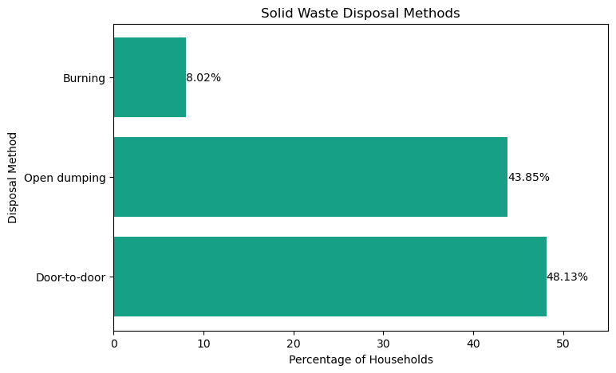

```python
plt.figure(figsize=(8,5))
bars = plt.barh(waste_split_percentage.index, waste_split_percentage.values, color='#16A085')
for bar in bars:
    plt.text(bar.get_width(),
             bar.get_y() + bar.get_height()/2,
             f"{bar.get_width():.2f}%",
             va='center')

plt.title("Solid Waste Disposal Methods")
plt.xlabel("Percentage of Households")
plt.ylabel("Disposal Method")
plt.xlim(0,55)
plt.show()
```

# 4.Open Defecation Status

```python
od = df['Open defecation in village'].value_counts(normalize=True) * 100
round(od,2)
```

```
Open defecation in village
No     63.16
Yes    36.84
Name: proportion, dtype: float64
```

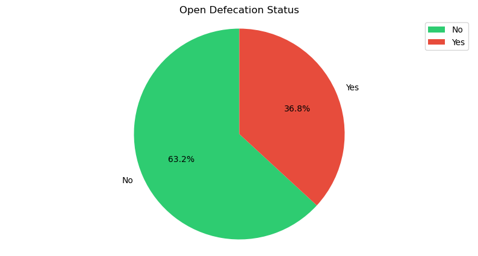

```python
plt.figure(figsize=(10,5))
plt.pie(od.values, labels=od.index, autopct='%1.1f%%', colors=['#2ECC71','#E74C3C'], startangle=90)
plt.title("Open Defecation Status")
plt.axis('equal')
plt.legend()
plt.show()
```

# Environmental & Disaster Resilience Indicators

# 1. Environmental Stress Index

```python
env_stress = df['Major environmental problems'].value_counts()
env_stress
```

```
Major environmental problems
Solid waste                                                                             248
Groundwater depletion                                                                   159
Flooding                                                                                111
Crop residue burning                                                                     56
Soil degradation                                                                         48
Flooding, Solid waste                                                                    32
Groundwater depletion, Solid waste                                                       30
Groundwater depletion, Flooding                                                          25
Crop residue burning, Soil degradation                                                   18
Crop residue burning, Solid waste                                                        16
Groundwater depletion, Flooding, Solid waste                                             15
Groundwater depletion, Crop residue burning                                              13
Soil degradation, Flooding                                                               10
Soil degradation, Solid waste                                                            10
Groundwater depletion, Soil degradation                                                  10
Groundwater depletion, Crop residue burning, Soil degradation                             9
Groundwater depletion, Soil degradation, Solid waste                                      9
Crop residue burning, Flooding                                                            6
Groundwater depletion, Crop residue burning, Soil degradation, Solid waste                6
Groundwater depletion, Crop residue burning, Flooding                                     5
Groundwater depletion, Crop residue burning, Solid waste                                  4
Soil degradation, Flooding, Solid waste                                                   4
Crop residue burning, Soil degradation, Solid waste                                       3
Groundwater depletion, Soil degradation, Flooding                                         2
Crop residue burning, Flooding, Solid waste                                               1
Groundwater depletion, Crop residue burning, Flooding, Solid waste                        1
Groundwater depletion, Crop residue burning, Soil degradation, Flooding                   1
Groundwater depletion, Crop residue burning, Soil degradation, Flooding, Solid waste      1
Groundwater depletion, Soil degradation, Flooding, Solid waste                            1
Crop residue burning, Soil degradation, Flooding                                          1
Name: count, dtype: int64
```

```python
env_stress = df['Major environmental problems'].str.split(',').explode().str.strip()
```

```python
env_stress_counts = env_stress.value_counts()
env_stress_counts
```

```
Major environmental problems
Solid waste              381
Groundwater depletion    291
Flooding                 216
Crop residue burning     141
Soil degradation         133
Name: count, dtype: int64
```

```python
percentage_env_stress_counts = round(env_stress.value_counts(normalize=True)*100,2)
percentage_env_stress_counts
```

```
Major environmental problems
Solid waste              32.79
Groundwater depletion    25.04
Flooding                 18.59
Crop residue burning     12.13
Soil degradation         11.45
Name: proportion, dtype: float64
```

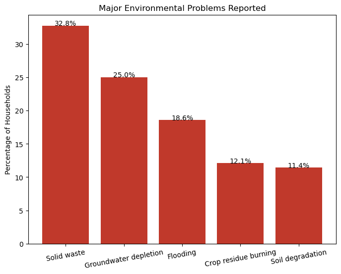

```python
plt.figure(figsize=(8,6))
bars = plt.bar(percentage_env_stress_counts.index, percentage_env_stress_counts.values, color='#C0392B')
for bar in bars:
    plt.text(bar.get_x()+bar.get_width()/2,
             bar.get_height(),
             f"{bar.get_height():.1f}%",
             ha='center')
plt.title("Major Environmental Problems Reported")
plt.ylabel("Percentage of Households")
plt.xticks(rotation=10)
plt.show()
```

# 2. Renewable Energy Adoption

```python
df['Renewable energy usage'].value_counts()
```

```
Renewable energy usage
Solar lights                         180
Biogas                                31
Solar lights, Solar pumps             27
Solar pumps                           20
Solar lights, Solar pumps, Biogas      5
Solar lights, Biogas                   5
Solar lights, None                     5
Biogas, None                           2
Solar pumps, Biogas                    2
Name: count, dtype: int64
```

```python
renewable = df['Renewable energy usage'].str.split(',').explode().str.strip()
```

```python
renewable_counts = renewable.value_counts()
renewable_counts
```

```
Renewable energy usage
Solar lights    222
Solar pumps      54
Biogas           45
None              7
Name: count, dtype: int64
```

```python
percentage_renewable_counts = round(renewable.value_counts(normalize=True)*100,2)
percentage_renewable_counts
```

```
Renewable energy usage
Solar lights    67.68
Solar pumps     16.46
Biogas          13.72
None             2.13
Name: proportion, dtype: float64
```

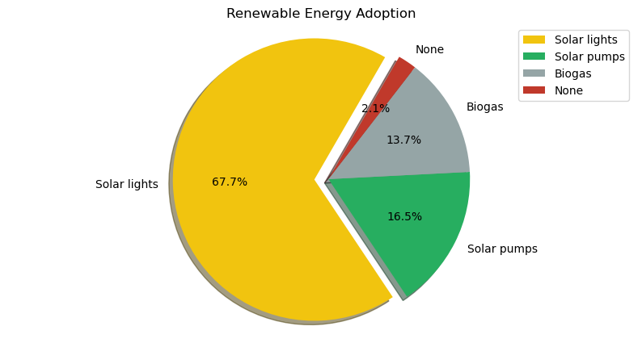

```python
plt.figure(figsize=(10,5))
plt.pie(percentage_renewable_counts.values, labels=percentage_renewable_counts.index, autopct='%1.1f%%', startangle=60, shadow = True,
        colors=['#F1C40F','#27AE60','#95A5A6', '#C0392B'], explode=[0.1,0,0,0])
plt.title("Renewable Energy Adoption")
plt.legend(loc='upper right')
plt.axis('equal')
plt.show()
```

# 3. Disaster Vulnerability Score

```python
df['Disaster vulnerability'].value_counts()
```

```
Disaster vulnerability
Flood                       179
Heatwave                     71
Drought                      28
Flood, Heatwave              26
Drought, Heatwave             8
Flood, Drought                7
Flood, None                   6
Heatwave, None                6
Drought, None                 1
Flood, Drought, Heatwave      1
Name: count, dtype: int64
```

```python
disaster = df['Disaster vulnerability'].str.split(',').explode().str.strip()
```

```python
disaster_count = disaster.value_counts()
disaster_count
```

```
Disaster vulnerability
Flood       219
Heatwave    112
Drought      45
None         13
Name: count, dtype: int64
```

```python
disaster_percent = round(disaster.value_counts(normalize=True)*100,2)
disaster_percent
```

```
Disaster vulnerability
Flood       56.30
Heatwave    28.79
Drought     11.57
None         3.34
Name: proportion, dtype: float64
```

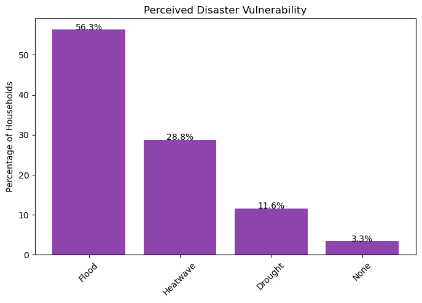

```python
plt.figure(figsize=(8,5))
bars = plt.bar(disaster_percent.index, disaster_percent.values, color='#8E44AD')
for bar in bars:
    plt.text(bar.get_x()+bar.get_width()/2,
             bar.get_height(),
             f"{bar.get_height():.1f}%",
             ha='center')
plt.title("Perceived Disaster Vulnerability")
plt.ylabel("Percentage of Households")
plt.xticks(rotation=45)
plt.show()
```

# 4. Pond Health Status

```python
pond_condition = df['Condition of pond'].value_counts()
pond_condition
```

```
Condition of pond
Highly polluted       376
Partially polluted    301
Clean                 178
Name: count, dtype: int64
```

```python
pond_percent = round(df['Condition of pond'].value_counts(normalize=True)*100,2)
pond_percent
```

```
Condition of pond
Highly polluted       43.98
Partially polluted    35.20
Clean                 20.82
Name: proportion, dtype: float64
```

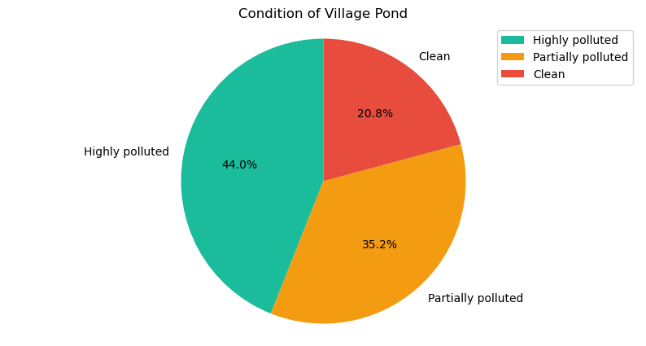

```python
plt.figure(figsize=(10,5))
plt.pie(pond_percent.values, labels=pond_percent.index, autopct='%1.1f%%', colors=['#1ABC9C','#F39C12','#E74C3C'], startangle=90)
plt.title("Condition of Village Pond")
plt.axis('equal')
plt.legend()
plt.show()
```

# Women Empowerment & Governance Indicators

# Female Labour Force Participation

```python
female_lfp = df['Household women  engaged in income activity'].value_counts()
female_lfp
```

```
Household women  engaged in income activity
No     595
Yes    260
Name: count, dtype: int64
```

```python
percentage_female_lfp = round(df['Household women  engaged in income activity'].value_counts(normalize=True)*100,2)
percentage_female_lfp
```

```
Household women  engaged in income activity
No     69.59
Yes    30.41
Name: proportion, dtype: float64
```

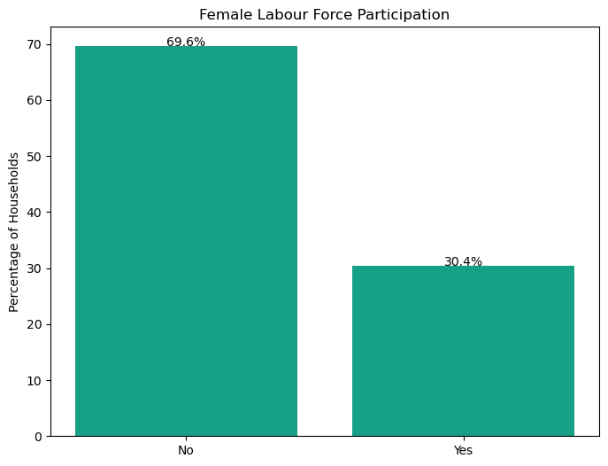

```python
plt.figure(figsize=(8,6))
bars = plt.bar(percentage_female_lfp.index, percentage_female_lfp.values, color='#16A085')

for bar in bars:
    plt.text(bar.get_x()+bar.get_width()/2,
             bar.get_height(),
             f"{bar.get_height():.1f}%",
             ha='center')

plt.title("Female Labour Force Participation")
plt.ylabel("Percentage of Households")
plt.show()
```

# Women Bank Account Ownership

```python
women_bank = df['Bank account in woman’s name'].value_counts()
women_bank
```

```
Bank account in woman’s name
Yes    653
No     202
Name: count, dtype: int64
```

```python
percentage_women_bank = round(df['Bank account in woman’s name'].value_counts(normalize=True)*100,2)
percentage_women_bank
```

```
Bank account in woman’s name
Yes    76.37
No     23.63
Name: proportion, dtype: float64
```

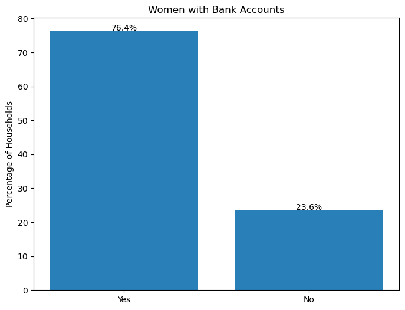

```python
plt.figure(figsize=(8,6))
bars = plt.bar(percentage_women_bank.index, percentage_women_bank.values, color='#2980B9')
for bar in bars:
    plt.text(bar.get_x()+bar.get_width()/2,
             bar.get_height(),
             f"{bar.get_height():.1f}%",
             ha='center')
plt.title("Women with Bank Accounts")
plt.ylabel("Percentage of Households")
plt.show()
```

# SHG Membership

```python
shg = df['SHG membership'].value_counts()
shg
```

```
SHG membership
No     745
Yes    110
Name: count, dtype: int64
```

```python
percentage_shg = round(df['SHG membership'].value_counts(normalize=True)*100,2)
percentage_shg
```

```
SHG membership
No     87.13
Yes    12.87
Name: proportion, dtype: float64
```

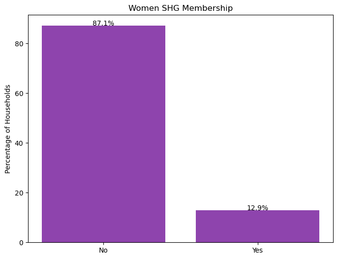

```python
plt.figure(figsize=(8,6))
bars = plt.bar(percentage_shg.index, percentage_shg.values, color='#8E44AD')
for bar in bars:
    plt.text(bar.get_x()+bar.get_width()/2,
             bar.get_height(),
             f"{bar.get_height():.1f}%",
             ha='center')
plt.title("Women SHG Membership")
plt.ylabel("Percentage of Households")
plt.show()
```

# Governance Awareness (Gram Sabha)

```python
gram_sabha = df['Awareness about Gram Sabha meetings'].value_counts()
gram_sabha
```

```
Awareness about Gram Sabha meetings
Yes    581
No     274
Name: count, dtype: int64
```

```python
percentage_gram_sabha = round(df['Awareness about Gram Sabha meetings'].value_counts(normalize=True)*100,2)
percentage_gram_sabha
```

```
Awareness about Gram Sabha meetings
Yes    67.95
No     32.05
Name: proportion, dtype: float64
```

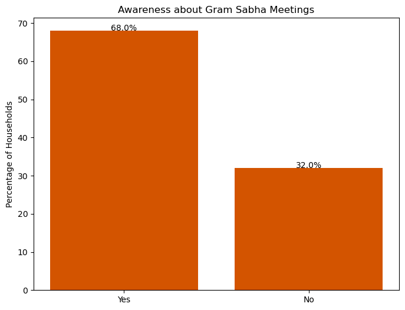

```python
plt.figure(figsize=(8,6))
bars = plt.bar(percentage_gram_sabha.index, percentage_gram_sabha.values, color='#D35400')
for bar in bars:
    plt.text(bar.get_x()+bar.get_width()/2,
             bar.get_height(),
             f"{bar.get_height():.1f}%",
             ha='center')
plt.title("Awareness about Gram Sabha Meetings")
plt.ylabel("Percentage of Households")
plt.show()
```

# Women Decision-Making Power

```python
decision = df['Role of women in decision-making'].value_counts()
decision
```

```
Role of women in decision-making
Moderate    535
High        208
Low         112
Name: count, dtype: int64
```

```python
percentage_decision = round(df['Role of women in decision-making'].value_counts(normalize=True)*100,2)
percentage_decision
```

```
Role of women in decision-making
Moderate    62.57
High        24.33
Low         13.10
Name: proportion, dtype: float64
```

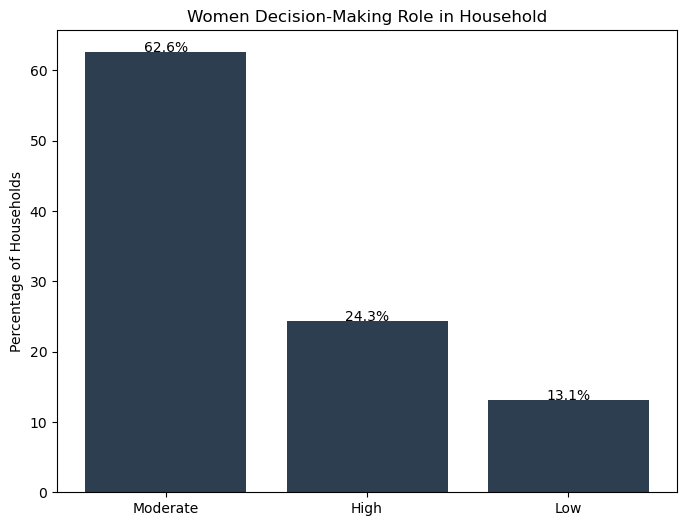

```python
plt.figure(figsize=(8,6))
bars = plt.bar(percentage_decision.index, percentage_decision.values, color='#2C3E50')
for bar in bars:
    plt.text(bar.get_x()+bar.get_width()/2,
             bar.get_height(),
             f"{bar.get_height():.1f}%",
             ha='center')
plt.title("Women Decision-Making Role in Household")
plt.ylabel("Percentage of Households")
plt.show()
```

# Strategie Gap Analysis (Qualitative to Quantitative)

# 1. Urgency Index (Most Urgent Village Needs)

```python
print(df['Most urgent need of the village'])
```

```
0                                     Road improvements
1                                       Drainage system
2                                            Healthcare
3           Transport, Dispensary and pond purification
4      All good there is gym in village,school ,every...
                             ...
850                                           dispensary
851    The village faces many problems like no high s...
852                           Transportation and health
853                                             Nothing
854    The village has problems like no high school, ...
Name: Most urgent need of the village, Length: 855, dtype: object
```

```python
urgency = df['Most urgent need of the village'].value_counts()
urgency
```

```
Most urgent need of the village
Hospital                                                                                                                                                       28
Employment                                                                                                                                                     18
Education                                                                                                                                                      15
Roads                                                                                                                                                          13
Health                                                                                                                                                         12
                                                                                                                                                               ..
Action against drugs                                                                                                                                            1
Darinage                                                                                                                                                        1
Awareness of bad effect about alcohol                                                                                                                           1
School and Hospital are far from home, polluted area                                                                                                            1
The village has problems like no high school, bad roads, few buses, and floods due to poor drainage. These issues affect education, travel, and daily life.     1
Name: count, Length: 547, dtype: int64
```

```python
urgency.count()
```

```
np.int64(547)
```

```python
urgency = df['Most urgent need of the village'].str.lower().str.strip()
urgency
```

```
0                                      road improvements
1                                        drainage system
2                                             healthcare
3            transport, dispensary and pond purification
4      all good there is gym in village,school ,every...
                             ...
850                                           dispensary
851    the village faces many problems like no high s...
852                            transportation and health
853                                              nothing
854    the village has problems like no high school, ...
Name: Most urgent need of the village, Length: 855, dtype: object
```

```python
urgency_split = urgency.str.split(r'[,.]').explode().str.strip()
urgency_split
```

```
0                     road improvements
1                       drainage system
2                            healthcare
3                             transport
3      dispensary and pond purification
                     ...
854     and floods due to poor drainage
854       these issues affect education
854                              travel
854                      and daily life
854
Name: Most urgent need of the village, Length: 1024, dtype: object
```

```python
urgency_split = urgency_split.replace('', pd.NA).dropna()
urgency_split
```

```
0                     road improvements
1                       drainage system
2                            healthcare
3                             transport
3      dispensary and pond purification
                     ...
854                           few buses
854     and floods due to poor drainage
854       these issues affect education
854                              travel
854                      and daily life
Name: Most urgent need of the village, Length: 968, dtype: object
```

```python
urgency_values = urgency_split.value_counts()
urgency_values.head(10)
```

```
Most urgent need of the village
hospital            43
education           32
employment          29
waste management    22
health              20
roads               19
drainage system     17
dispensary          16
water               15
transport           14
Name: count, dtype: int64
```

```python
category_map = {
    "hospital":"health",
    "hospitals":"health",
    "healthcare":"health",
    "health center":"health",
    "health facilities":"health",
    "medical":"health",
    "dispensary":"health",

    "roads":"roads",
    "road":"roads",
    "better roads":"roads",
    "road repair":"roads",
    "road development":"roads",
    "roads development":"roads",
    "good roads":"roads",

    "drainage":"sanitation",
    "drainage system":"sanitation",
    "sewage":"sanitation",
    "sewerage":"sanitation",
    "sewerage system":"sanitation",
    "sewage system":"sanitation",
    "severage":"sanitation",
    "waste management":"sanitation",
    "waste water treatment":"sanitation",

    "water":"water",
    "clean water":"water",
    "water supply":"water",
    "water management":"water",

    "school":"education",
    "education services":"education",

    "transport":"transport",
    "travelling":"transport",

    "cleaning":"cleanliness",
    "cleanliness":"cleanliness",
    "cleanness":"cleanliness"}
```

```python
urgency_clean = urgency_split.replace(category_map)
urgency_summary = urgency_clean.value_counts()
urgency_summary.head(10)
```

```
Most urgent need of the village
health           104
sanitation        91
roads             57
education         44
employment        29
water             26
transport         18
cleanliness       17
pond cleaning     11
no                 9
Name: count, dtype: int64
```

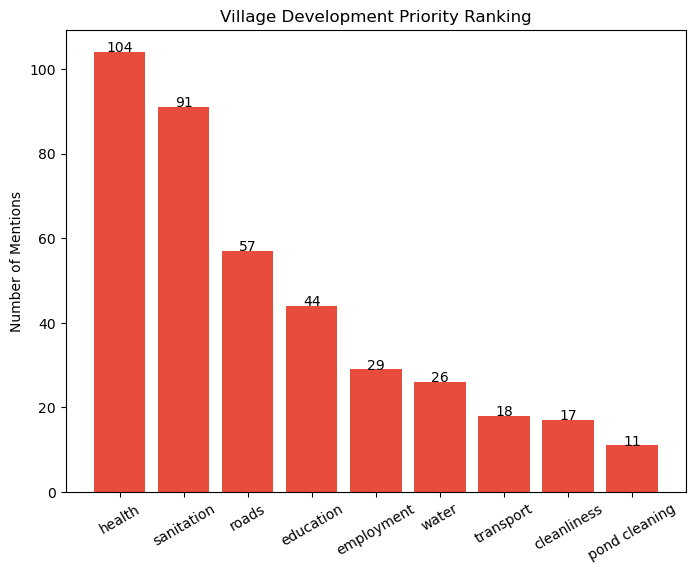

```python
plt.figure(figsize=(8,6))
bars = plt.bar(urgency_summary.head(9).index, urgency_summary.head(9).values, color='#E74C3C')
for bar in bars:
    plt.text(bar.get_x()+bar.get_width()/2,
             bar.get_height(),
             f"{bar.get_height()}",
             ha='center')
plt.title("Village Development Priority Ranking")
plt.ylabel("Number of Mentions")
plt.xticks(rotation=30)
plt.show()
```

# 2. Skill Gap Analysis

```python
skill_trained = df['Skill-trained member in household'].value_counts()
skill_trained
```

```
Skill-trained member in household
Yes    538
No     317
Name: count, dtype: int64
```

```python
percentage_skill_trained = round(df['Skill-trained member in household'].value_counts(normalize=True)*100,2)
percentage_skill_trained
```

```
Skill-trained member in household
Yes    62.92
No     37.08
Name: proportion, dtype: float64
```

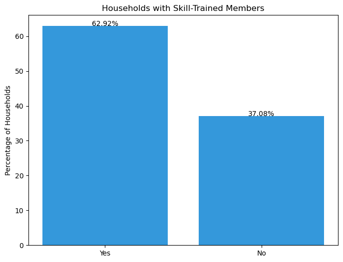

```python
plt.figure(figsize=(8,6))
bars = plt.bar(percentage_skill_trained.index, percentage_skill_trained.values, color='#3498DB')
for bar in bars:
    plt.text(bar.get_x()+bar.get_width()/2,
             bar.get_height(),
             f"{bar.get_height():.2f}%",
             ha='center')
plt.title("Households with Skill-Trained Members")
plt.ylabel("Percentage of Households")
plt.show()
```

```python
df['Skills required'].value_counts()
```

```
Skills required
Agriculture                                              313
Computer                                                 117
Tailoring                                                 81
Driving                                                   54
Agriculture, Tailoring                                    37
Computer, Electrical                                      27
Electrical                                                22
Agriculture, Driving                                      22
Tailoring, Computer                                       19
Agriculture, Tailoring, Computer, Electrical, Driving     18
Agriculture, Computer                                     18
Tailoring, Computer, Electrical                           13
Computer, Electrical, Driving                             11
Agriculture, Tailoring, Computer                          11
Computer, Driving                                         11
Agriculture, Tailoring, Driving                           10
Agriculture, Electrical, Driving                           9
Agriculture, Computer, Electrical                          8
Tailoring, Computer, Electrical, Driving                   8
Agriculture, Electrical                                    6
Tailoring, Driving                                         6
Agriculture, Computer, Driving                             5
Agriculture, Tailoring, Computer, Driving                  5
Agriculture, Tailoring, Computer, Electrical               4
Electrical, Driving                                        4
Agriculture, Tailoring, Electrical, Driving                4
Agriculture, Computer, Electrical, Driving                 3
Agriculture, Tailoring, Electrical                         3
Tailoring, Electrical, Driving                             2
Tailoring, Electrical                                      2
Tailoring, Computer, Driving                               2
Name: count, dtype: int64
```

```python
skills_required = df['Skills required'].str.split(',').explode().str.strip()
```

```python
skills_required_counts = skills_required.value_counts()
skills_required_counts
```

```
Skills required
Agriculture    476
Computer       280
Tailoring      225
Driving        174
Electrical     144
Name: count, dtype: int64
```

```python
percentage_skills_required = round(skills_required.value_counts(normalize=True)*100,2)
percentage_skills_required
```

```
Skills required
Agriculture    36.64
Computer       21.56
Tailoring      17.32
Driving        13.39
Electrical     11.09
Name: proportion, dtype: float64
```

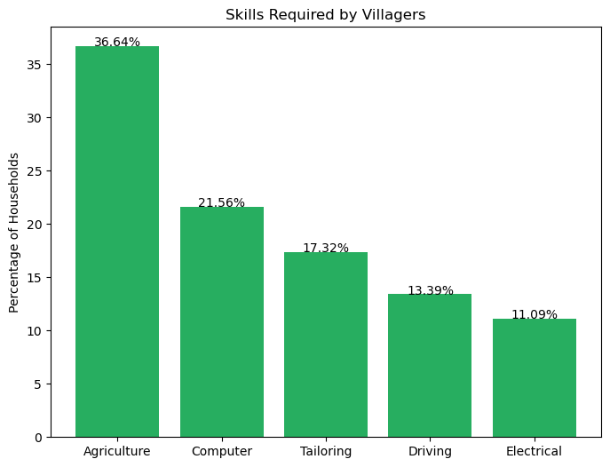

```python
plt.figure(figsize=(8,6))
bars = plt.bar(percentage_skills_required.index, percentage_skills_required.values, color='#27AE60')
for bar in bars:
    plt.text(bar.get_x()+bar.get_width()/2,
             bar.get_height(),
             f"{bar.get_height():.2f}%",
             ha='center')
plt.title("Skills Required by Villagers")
plt.ylabel("Percentage of Households")
plt.show()
```

# A. Poverty–Education–Migration Cycle Analysis

# 1. Income vs School Dropout (Poverty → Education)

```python
income_dropout = pd.crosstab(df['Approx. Annual Household Income'], df['School dropout cases  in the household'], normalize='index') * 100
income_dropout
```

| School dropout cases in the household Approx. Annual Household Income | NO | Partia | YES |
| --- | --- | --- | --- |
| <1 lakh | 75.000000 | 5.281690 | 19.718310 |
| 1-3 lakh | 78.694158 | 5.841924 | 15.463918 |
| 3-5 lakh | 84.180791 | 6.779661 | 9.039548 |
| >5 lakh | 85.436893 | 3.883495 | 10.679612 |

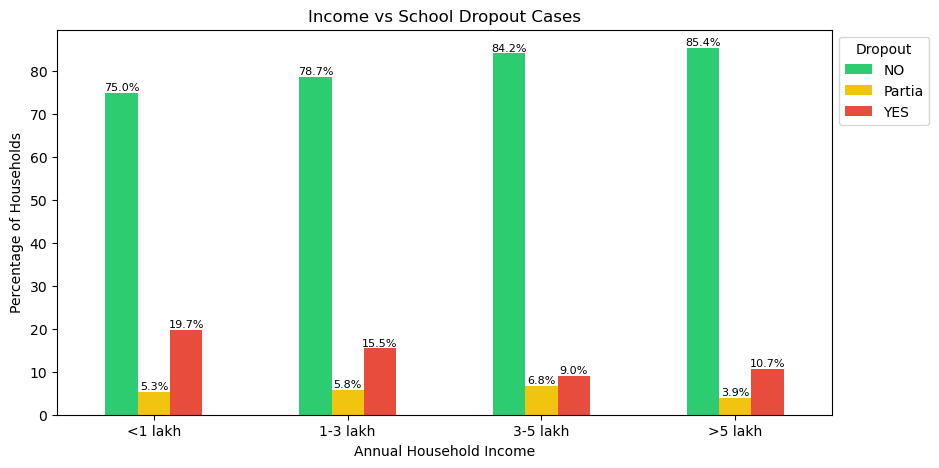

```python
bars = income_dropout.plot(kind='bar', figsize=(10,5), color=['#2ECC71','#F1C40F','#E74C3C'])
for bar in bars.patches:
    plt.text(bar.get_x() + bar.get_width()/2,
             bar.get_height()+0.1,
             f"{bar.get_height():.1f}%",
             ha='center',
             va='bottom',
             fontsize=8)
plt.title("Income vs School Dropout Cases")
plt.ylabel("Percentage of Households")
plt.xlabel("Annual Household Income")
plt.xticks(rotation=0)
plt.legend(title="Dropout", bbox_to_anchor=(1,1), loc='upper left')
plt.show()
```

# 2. Migration vs Reason for Dropout (Drivers)

```python
migration_dropout_reason = round(pd.crosstab(df['Migration for employment'], df['Reason for dropout'], normalize='index') * 100,2)
migration_dropout_reason
```

| Reason for dropout Migration for employment | Domestic work | Domestic work, Lack of interest | Financial | Financial, Domestic work | Financial, Domestic work, Lack of interest | Financial, Lack of interest | Financial, Migration | Lack of interest | Migration |
| --- | --- | --- | --- | --- | --- | --- | --- | --- | --- |
| Permanent | 17.81 | 1.37 | 31.51 | 4.11 | 0.00 | 0.00 | 4.11 | 16.44 | 24.66 |
| Seasonal | 20.83 | 0.00 | 32.29 | 4.17 | 1.04 | 1.04 | 2.08 | 29.17 | 9.38 |

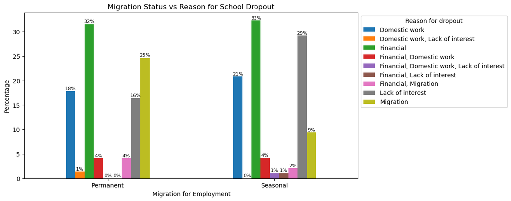

```python
bars = migration_dropout_reason.plot(kind='bar', figsize=(10,5))
for bar in bars.patches:
    plt.text(bar.get_x() + bar.get_width()/2,
             bar.get_height()+0.1,
             f"{bar.get_height():.0f}%",
             ha='center',
             va='bottom',
             fontsize=8)
plt.title("Migration Status vs Reason for School Dropout")
plt.ylabel("Percentage")
plt.xlabel("Migration for Employment")
plt.xticks(rotation=0)
plt.legend(title="Reason for dropout", bbox_to_anchor=(1,1), loc='upper left')
plt.show()
```